# compare-expression-distributions-in-different-comparison cohorts 2023.11.21 11.24.15

hbeale

November 27, 2023

Version 2023.11.21_11.24.15 - focuses on genes found only relative to TCGA, not relative to any other cohort. Previous versions focused on outliers detected relative to TCGA and not treehouse, irrespective of whatever other cohorts they were outliers in

```r
outliers <- read_tsv("../input_data/druggable_outliers_from_treehouse_and_other_cohorts_2023_11_09-13_46_32_2023.tsv") %>%
  mutate(high_level_cohort = ifelse(str_detect(comparison_cohort, "Treehouse"),
                                    "Treehouse",
                                    comparison_cohort))
```

# COMPARE DISTRIBUTIONS FOR FOR OUTLIERS ACROSS COHORTS

```r
outlier_genes_detected <- unique(outliers$gene)

expr <- read_tsv("../input_data/druggable_TumorCompendium_v11_PolyA_hugo_log2tpm_58581genes_2020-04-09.tsv.gz") %>%
  rename(Sample_ID = TH_id) %>%
  filter(Gene %in% outlier_genes_detected)
stanford_samples  <- read_tsv("../gather_input_data/comparison_to_non_CARE_cohorts/data/TH03_TH34_rollup.sample_list.txt",
                              col_names = "Sample_ID") %>%
  mutate(cohort = "TH03_TH34")
TCGA_samples  <- read_tsv("../gather_input_data/comparison_to_non_CARE_cohorts/data/TCGA_rollup.sample_list.txt",
                              col_names = "Sample_ID") %>%
  mutate(cohort = "TCGA")
PEDAYA_samples  <- read_tsv("../gather_input_data/comparison_to_non_CARE_cohorts/data/PEDAYA_rollup.sample_list.txt",
                              col_names = "Sample_ID") %>%
  mutate(cohort = "PEDAYA")
pan_cancer_samples <- expr %>%
  select(Sample_ID) %>%
  distinct() %>%
  mutate(cohort = "Treehouse_pc")


samples_in_cohorts <- bind_rows(
  stanford_samples,
  TCGA_samples,
  PEDAYA_samples,
  pan_cancer_samples)


tabyl(samples_in_cohorts,
      cohort)
```

```
##        cohort     n    percent
##        PEDAYA  2814 0.11045257
##          TCGA  9806 0.38489618
##     TH03_TH34   110 0.00431762
##  Treehouse_pc 12747 0.50033363
```

# expression in samples not in the compendium

```r
rsem_path <- "../input_data/non_compendium_expression"

gene_name_conversion <- read_tsv(file.path(rsem_path,
                                           "EnsGeneID_Hugo_Observed_Conversions.txt"))
relevant_gene_name_conversion <- gene_name_conversion %>%
  filter(HugoID %in% outlier_genes_detected)

rsem_kitchen_sink_data <- tibble(file_name = list.files(
  path = rsem_path,
  pattern = "_rsem_genes.results")) %>%
  rowwise() %>%
  mutate(rsem_raw = list(read_tsv(file.path(rsem_path, file_name),
                                     show_col_types = FALSE
                                     ))) %>%
  unnest(rsem_raw) %>%
  filter(gene_id %in% relevant_gene_name_conversion$EnsGeneID) %>%
  mutate(Sample_ID = str_extract(file_name, "TH[R]?[0-9]{2}_[0-9]{4}_S[0-9]{2}")) %>%
  left_join(relevant_gene_name_conversion,
            by=c("gene_id"="EnsGeneID")) %>%
    group_by(Sample_ID, HugoID) %>%
    summarize(sum_TPM = sum(TPM),
              n=n()) %>%
    mutate(log2TPM1 = log2(sum_TPM +1))
table(rsem_kitchen_sink_data$n)
```

```
##
##   1   2
## 275   5
```

```r
patient_expression_from_rsem_files <- rsem_kitchen_sink_data %>%
  select(gene = HugoID,
         log2TPM1,
         Sample_ID)

patient_expression_from_compendia <- outliers %>%
  select(Sample_ID, gene) %>%
  distinct() %>%
  left_join(expr,
            by=c("Sample_ID", "gene"="Gene")) %>%
  na.omit() # excludes samples not in compendium

patient_expression <- bind_rows(
  patient_expression_from_rsem_files,
  patient_expression_from_compendia)

length(outlier_genes_detected)
```

```
## [1] 56
```

# Calculate statistics for each cohort

```r
cohort_thresholds_raw <- left_join(samples_in_cohorts,
                                   expr,
                                   by=c("Sample_ID")) %>%
  group_by(Gene, cohort) %>%
  summarize(q25 = quantile(log2TPM1, 0.25),
            median = median(log2TPM1),
            q75 = quantile(log2TPM1, 0.75),
            IQR = q75-q25,
            up_outlier_threshold = q75 + (1.5*IQR))
```

# assess changes for all genes

```r
cohort_thresholds <- cohort_thresholds_raw %>%
  pivot_longer(c(-Gene, -cohort)) %>%
  pivot_wider(names_from = cohort, values_from = value) %>%
  mutate(change_in_ped_relative_to_TCGA =
              (PEDAYA - TCGA) / TCGA,
         change_in_treehouse_relative_to_TCGA =
            (Treehouse_pc - TCGA) / Treehouse_pc)
```

# changes plotted

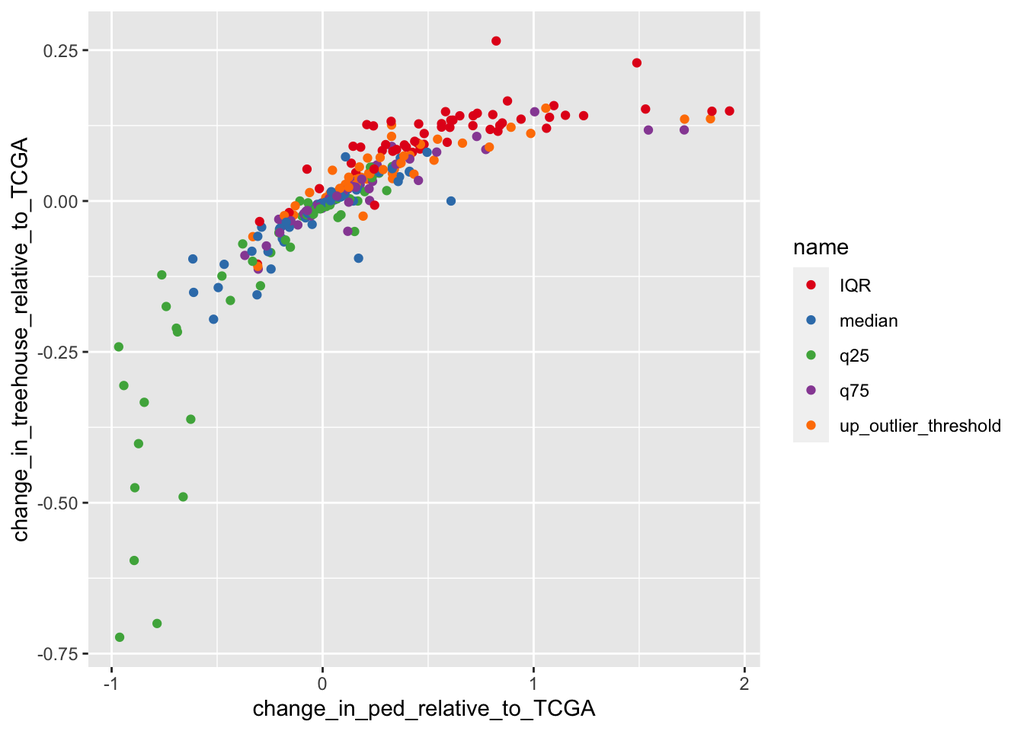

```r
ggplot(cohort_thresholds) +
  geom_point(aes(x=change_in_ped_relative_to_TCGA,
                 y=change_in_treehouse_relative_to_TCGA,
                 color = name)) +
  scale_color_brewer(palette = "Set1")
```

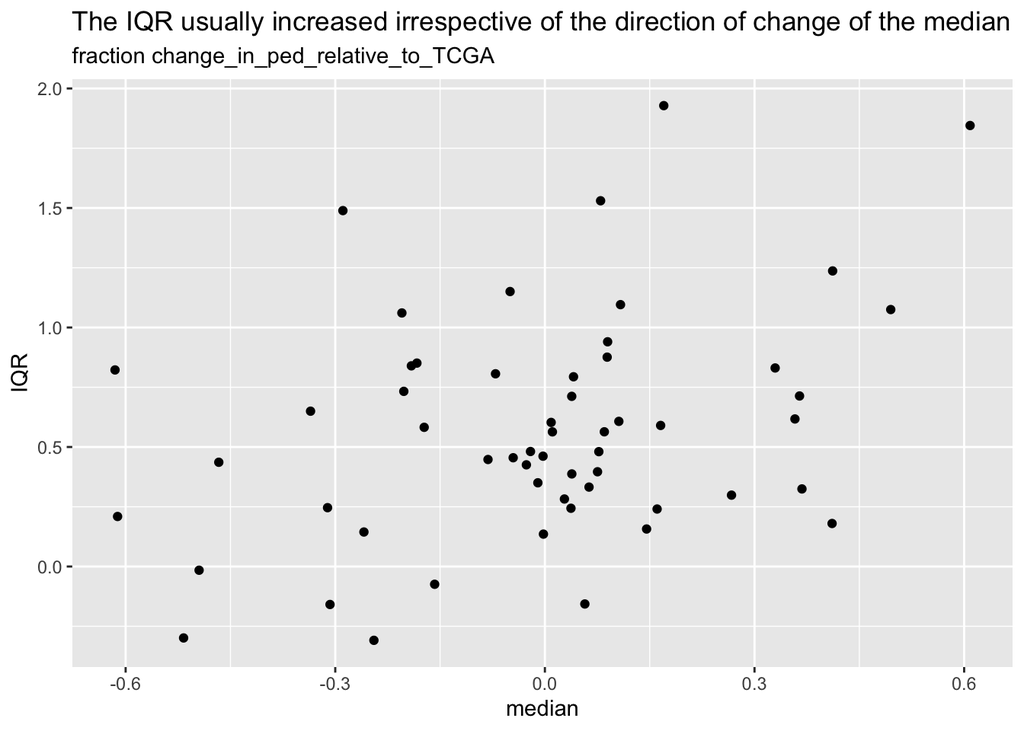

```r
cohort_thresholds %>%
  filter(name %in% c("median", "IQR")) %>%
  select(Gene, name, change_in_ped_relative_to_TCGA) %>%
  pivot_wider(names_from = name,
              values_from = change_in_ped_relative_to_TCGA) %>%
  ggplot +
  geom_point(aes(x=median, y=IQR)) +
  ggtitle("The IQR usually increased irrespective of the direction of change of the median", "fraction change_in_ped_relative_to_TCGA")
```

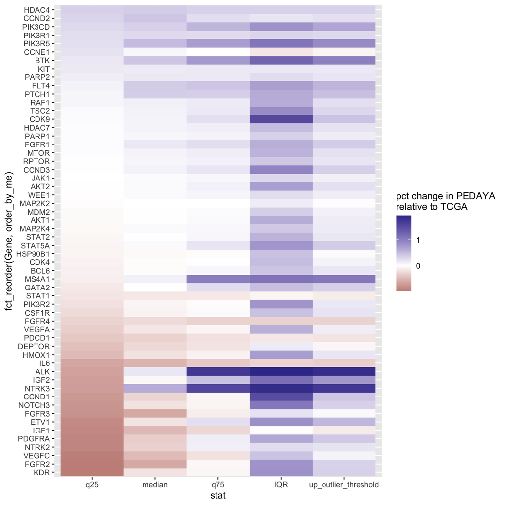

```r
cohort_thresholds_for_plot <- cohort_thresholds %>%
         rename(stat = name) %>%
  mutate(stat = factor(stat, levels = c("q25", "median", "q75", "IQR", "up_outlier_threshold"))) %>%
  group_by(Gene) %>%
         mutate(order_by_me = change_in_ped_relative_to_TCGA[stat == "q25"])

# %>%
#   ungroup %>%
#   mutate(Gene = factor(Gene) %>% fct_reorder(Gene, order_by_me, .fun = min))
# levels(cohort_thresholds_for_plot$Gene)


ggplot(cohort_thresholds_for_plot) +
  #geom_tile(aes(x=stat, y= Gene, fill = change_in_ped_relative_to_TCGA)) +
  geom_tile(aes(x=stat, y= fct_reorder(Gene, order_by_me), fill = change_in_ped_relative_to_TCGA)) +
  scale_fill_gradient2("pct change in PEDAYA\nrelative to TCGA")
```

```r
#geom_tile(aes(x=stat, y= fct_reorder(Gene, change_in_ped_relative_to_TCGA), fill = change_in_ped_relative_to_TCGA))
```

# plot boxplots for TCGA and PEDAYA

```r
TP_cohort_expr <- left_join(samples_in_cohorts %>%
                                     filter(cohort %in% c("PEDAYA", "TCGA")),
                                   expr,
                                   by=c("Sample_ID"))
```

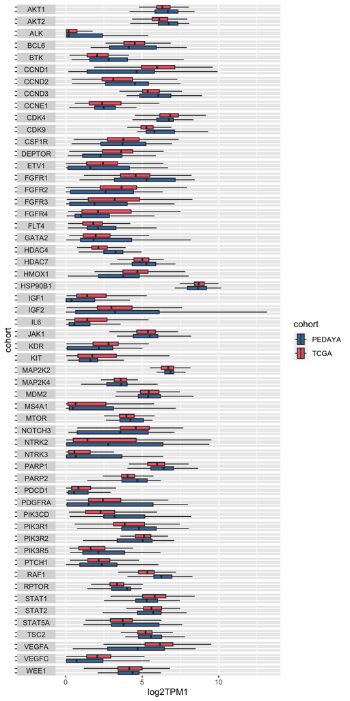

```r
TP_cohort_expr_subset <- TP_cohort_expr %>%
  slice_sample(n = 10000)

ggplot(TP_cohort_expr_subset) +
  geom_boxplot(aes(y=cohort, x=log2TPM1,
                   fill = cohort),
               outlier.shape = NA) +
  facet_wrap(~Gene, ncol = 1,
             strip.position = "left") +
 theme(strip.text.y.left = element_text(angle = 0),
       axis.text.y = element_blank(),
        panel.spacing = unit(0.2, "lines"))  +
  scale_fill_bright()
```

```r
table(outliers$comparison_cohort)
```

```
##
##       PEDAYA         TCGA    TH03_TH34 Treehouse_pc Treehouse_pd
##           26           98           53           72           38
```

```r
TCGA_only_outliers <- outliers %>%
  group_by(gene, Sample_ID) %>%
  mutate(TCGA_only = "TCGA" %in% comparison_cohort &
           n() == 1) %>%
  filter(TCGA_only) %>%
  arrange(Sample_ID, gene)

n_distinct(TCGA_only_outliers$gene)
```

```
## [1] 16
```

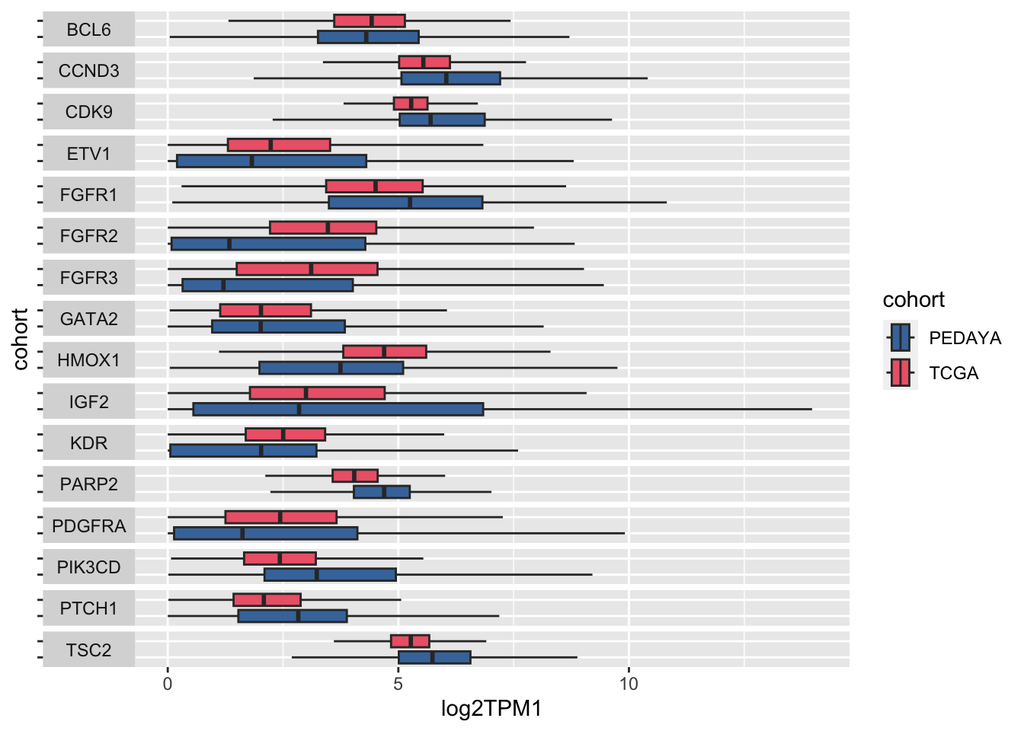

```r
TP_cohort_expr_of_TCGA_only_outliers <- TP_cohort_expr %>%
         filter(Gene %in% TCGA_only_outliers$gene)

ggplot(TP_cohort_expr_of_TCGA_only_outliers) +
  geom_boxplot(aes(y=cohort, x=log2TPM1,
                   fill = cohort),
               outlier.shape = NA) +
  facet_wrap(~Gene, ncol = 1,
             strip.position = "left") +
 theme(strip.text.y.left = element_text(angle = 0),
       axis.text.y = element_blank(),
        panel.spacing = unit(0.2, "lines"))  +
  scale_fill_bright()
```

```r
manual_annotation_of_pedaya_relative_to_TCGA <- tribble(
  ~Gene, ~IQR, ~shift,
  "BCL6", "wider", "none",
  "CCND1", "wider", "lower",
  "CCND3", "wider", "higher",
  "CDK9", "wider", "higher",
  "ETV1", "wider", "lower",
  "FGFR1", "wider", "higher",
  "FGFR2", "wider", "lower",
  "FGFR3", "wider", "lower",
  "GATA2", "wider", "none",
  "HMOX1", "wider", "lower",
  "IGF2", "wider", "none",
  "KDR", "wider", "lower",
  "MTOR", "similar", "higher",
  "PARP2", "similar", "higher",
  "PDGFRA", "wider", "lower",
  "PIK3CD", "wider", "higher",
  "PTCH1", "wider", "higher",
  "RPTOR", "similar", "higher",
  "TSC2", "wider", "higher",
  "VEGFA", "wider", "lower") %>%
  filter(Gene %in% TCGA_only_outliers$gene)

# cat(paste0("\"", unique(sort(TCGA_only_outliers$gene)), "\""), sep = ",\n")
```

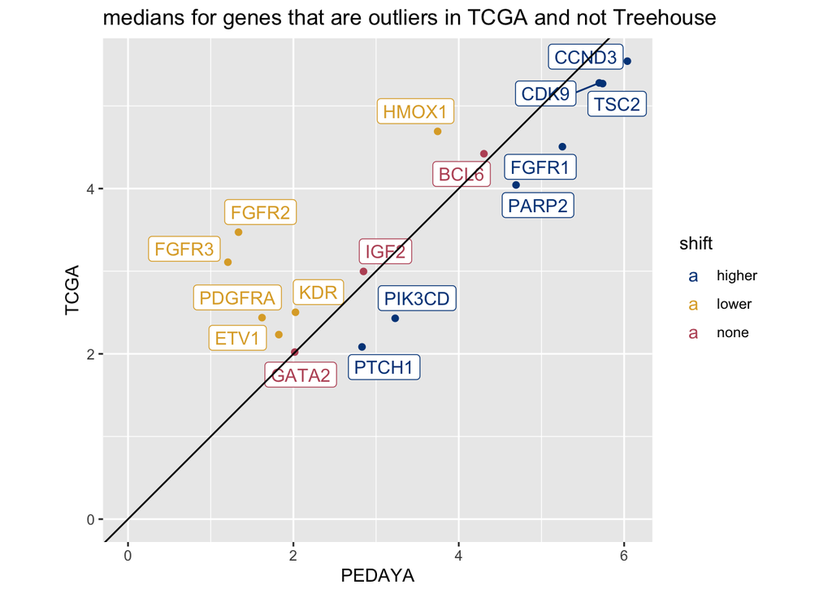

```r
anno_cohort_thresholds_of_TCGA_only_outliers <-
  left_join(cohort_thresholds_for_plot %>%
              filter(Gene %in% TCGA_only_outliers$gene),
            manual_annotation_of_pedaya_relative_to_TCGA)
  ggplot(anno_cohort_thresholds_of_TCGA_only_outliers  %>%
              filter(stat == "median"),
         aes(x=PEDAYA, y=TCGA, color = shift)) +
  #geom_histogram(aes(x=change_in_ped_relative_to_TCGA))
  geom_point() +
  geom_label_repel(aes(label = Gene)) +
  geom_abline() +
  coord_equal() +
  #scale_y_continuous(breaks = c(0:3)) +
  expand_limits(y=0,x=0) +
  ggtitle("medians for genes that are outliers in TCGA and not Treehouse") +
  scale_color_highcontrast()
```

```r
# cohort_thresholds_for_plot %>%
#   filter(Gene %in% TCGA_only_outliers$gene) %>%
#   filter(stat == "median") %>%
#   arrange(change_in_ped_relative_to_TCGA)
```

# Compare IQRs

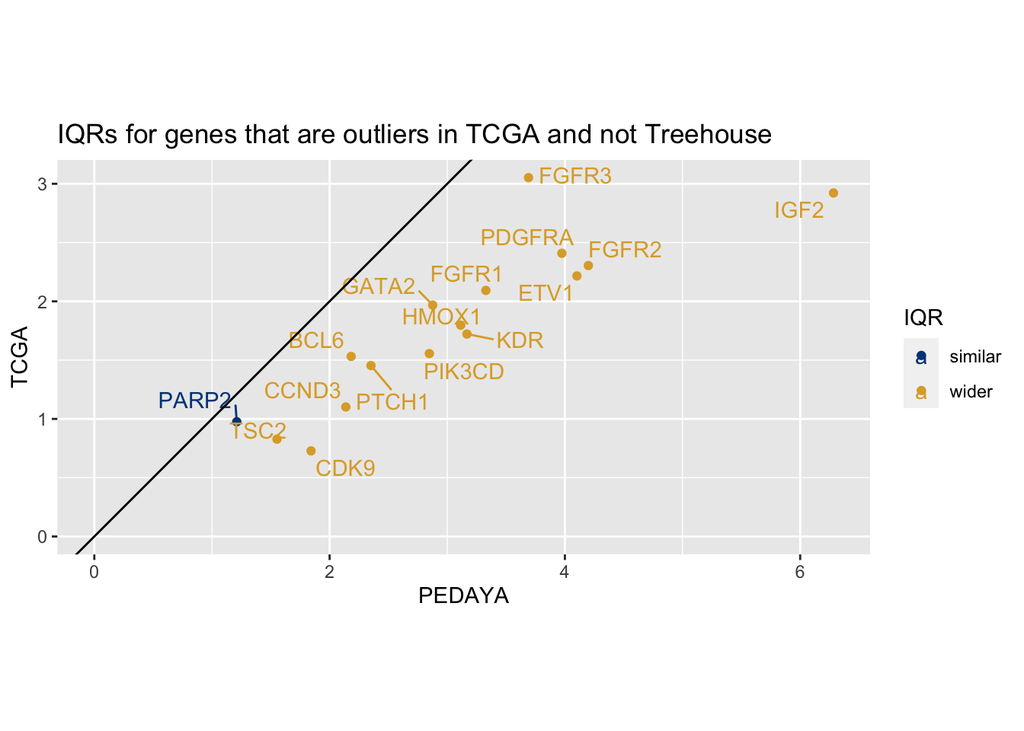

```r
ggplot(anno_cohort_thresholds_of_TCGA_only_outliers  %>%
         filter(stat == "IQR"),
       aes(x=PEDAYA, y=TCGA, color = IQR)) +
  #geom_histogram(aes(x=change_in_ped_relative_to_TCGA))
  geom_point() +
  geom_text_repel(aes(label = Gene)) +
  geom_abline() +
  coord_equal() +
  scale_y_continuous(breaks = c(0:3)) +
  expand_limits(y=0,x=0) +
  ggtitle("IQRs for genes that are outliers in TCGA and not Treehouse") +
  scale_color_highcontrast()
```

# Review data to identify a good quantitative IQR cutoff

```r
anno_cohort_thresholds_of_TCGA_only_outliers %>%
  mutate(abs_change = PEDAYA-TCGA) %>%
  select(Gene, stat, PEDAYA, TCGA,
         pct_change = change_in_ped_relative_to_TCGA,
         abs_change,
         IQR, shift) %>%
  arrange(abs_change) %>% # change to pct_change to view alternative consideration
  adorn_pct_formatting(,,,pct_change) %>%
  filter(stat == "IQR") %>%
  kbl(digits = c(NA, NA, 1, 1, NA, 2, NA, NA)) %>%
  kable_styling(full_width = F)
```

| Gene | stat | PEDAYA | TCGA | pct_change | abs_change | IQR | shift |
| --- | --- | --- | --- | --- | --- | --- | --- |
| PARP2 | IQR | 1.2 | 1.0 | 24.1% | 0.23 | similar | higher |
| FGFR3 | IQR | 3.7 | 3.1 | 20.9% | 0.64 | wider | lower |
| BCL6 | IQR | 2.2 | 1.5 | 42.5% | 0.65 | wider | none |
| TSC2 | IQR | 1.6 | 0.8 | 87.6% | 0.73 | wider | higher |
| PTCH1 | IQR | 2.4 | 1.5 | 61.7% | 0.90 | wider | higher |
| GATA2 | IQR | 2.9 | 2.0 | 46.2% | 0.91 | wider | none |
| CCND3 | IQR | 2.1 | 1.1 | 94.0% | 1.04 | wider | higher |
| CDK9 | IQR | 1.8 | 0.7 | 153.0% | 1.11 | wider | higher |
| FGFR1 | IQR | 3.3 | 2.1 | 59.0% | 1.24 | wider | higher |
| PIK3CD | IQR | 2.8 | 1.6 | 83.1% | 1.29 | wider | higher |
| HMOX1 | IQR | 3.1 | 1.8 | 73.3% | 1.32 | wider | lower |
| KDR | IQR | 3.2 | 1.7 | 84.0% | 1.45 | wider | lower |
| PDGFRA | IQR | 4.0 | 2.4 | 65.0% | 1.57 | wider | lower |
| ETV1 | IQR | 4.1 | 2.2 | 85.1% | 1.89 | wider | lower |
| FGFR2 | IQR | 4.2 | 2.3 | 82.2% | 1.90 | wider | lower |
| IGF2 | IQR | 6.3 | 2.9 | 115.0% | 3.36 | wider | none |

```r
# IQR change greater than 0.5 log2TPM1

# percent cutoff doesn't really work, because some relatively small pcts are large in log2tpm1 space,
# e.g. FGFR3, BCL6, wider
```

# Review data to see identify a good quantitative shift cutoff

```r
anno_cohort_thresholds_of_TCGA_only_outliers %>%
  mutate(abs_change = PEDAYA-TCGA) %>%
  select(Gene, stat, PEDAYA, TCGA,
         pct_change = change_in_ped_relative_to_TCGA,
         abs_change,
         IQR, shift) %>%
  arrange(abs_change) %>%
  adorn_pct_formatting(,,,pct_change) %>%
  filter(stat == "median") %>%
  kbl(digits = c(NA, NA, 1, 1, NA, 2, NA, NA)) %>%
  kable_styling(full_width = F)
```

| Gene | stat | PEDAYA | TCGA | pct_change | abs_change | IQR | shift |
| --- | --- | --- | --- | --- | --- | --- | --- |
| FGFR2 | median | 1.3 | 3.5 | -61.5% | -2.14 | wider | lower |
| FGFR3 | median | 1.2 | 3.1 | -61.2% | -1.90 | wider | lower |
| HMOX1 | median | 3.7 | 4.7 | -20.2% | -0.95 | wider | lower |
| PDGFRA | median | 1.6 | 2.4 | -33.5% | -0.82 | wider | lower |
| KDR | median | 2.0 | 2.5 | -19.1% | -0.48 | wider | lower |
| ETV1 | median | 1.8 | 2.2 | -18.3% | -0.41 | wider | lower |
| IGF2 | median | 2.8 | 3.0 | -5.0% | -0.15 | wider | none |
| BCL6 | median | 4.3 | 4.4 | -2.6% | -0.12 | wider | none |
| GATA2 | median | 2.0 | 2.0 | -0.3% | -0.01 | wider | none |
| CDK9 | median | 5.7 | 5.3 | 8.0% | 0.42 | wider | higher |
| TSC2 | median | 5.7 | 5.3 | 8.9% | 0.47 | wider | higher |
| CCND3 | median | 6.0 | 5.5 | 9.0% | 0.50 | wider | higher |
| PARP2 | median | 4.7 | 4.0 | 16.1% | 0.65 | similar | higher |
| PTCH1 | median | 2.8 | 2.1 | 35.8% | 0.75 | wider | higher |
| FGFR1 | median | 5.3 | 4.5 | 16.6% | 0.75 | wider | higher |
| PIK3CD | median | 3.2 | 2.4 | 33.0% | 0.80 | wider | higher |

```r
# if PEDAYA median is 0.25 higher or lower than TCGA median, the shift is higher or lower, respectively

# percent cutoff doesn't really work, because some relatively small pcts are large in log2tpm1 space,
```

# Summary of differences

```r
#manual_annotation_of_pedaya_relative_to_TCGA

tabyl(manual_annotation_of_pedaya_relative_to_TCGA, IQR)
```

```
##      IQR  n percent
##  similar  1  0.0625
##    wider 15  0.9375
```

```r
tabyl(manual_annotation_of_pedaya_relative_to_TCGA, shift)
```

```
##   shift n percent
##  higher 7  0.4375
##   lower 6  0.3750
##    none 3  0.1875
```

# Text summary

Each sample in the study was compared to TCGA, PEDAYA, Stanford and the full Treehouse compendium. Often genes would be identified as outliers with respect to multiple cohorts. We investigated the exceptions, genes found as outliers with respect to only one cohort. The cohort with the largest number of uniquely detected outliers was TCGA, We analyzed the distribution of expression for the outlier genes that were identified in any samples by comparison with TCGA and no other cohorts. Because the addition of pediatric samples is the primary difference between TCGA and the other cohorts, we focussed on comparing the PEDAYA cohort and TCGA

Of those 16, 15 had wider distributions (>0.5log2(TPM+1) bigger) in PEDAYA than TCGA, while one was similar. For 7, the median was higher (by more than 0.25 log2TPM1) in PEDAYA than TCGA. For 6, the median was lower (by more than 0.25 log2TPM1) in PEDAYA than TCGA. For 3, the medians were similar in PEDAYA and TCGA.